# Hemolymph_analysis

Samuel Gurr

2023-05-09

- Last updates: May 9/21/2023

# OA Reexposure Challenge

### May 2023: F2 Adult Bay scallops exposed to a two-week full-reciprocal pCO2 challenge

### Objective: plot and analyze flow cytometry data for (a) SYBR green and propidium iodide - cell viability (b) MitoSox gree - mitochondrial ROS (c) JC-10 - mitochondrial membrane potential corrected for CCCP

## Load flow cytometry data

**NOTE**: the statistics option ion C6 PLus software was used to compile the data (i.e. mean FL1) - the following loaded data file was assembled manually to include the sample metadata (i.e. data, treatments, etc.) as well as these flow cytometry data

```r
# getwd()
# read data
data  <- read.csv(file="../Data/FlowCytometry/Hemolymph_data_raw.csv", header = TRUE) %>%
            dplyr::mutate(Scallop_ID = as.character(Scallop_ID))

# notes: the dissection team and hemolymph extration team were given
# sheet to note if/when there was a sampling error with individuals

# of particular interest was notes of 'hitting the gut' from the appearance of
# extracted hemolymph - this was particularly confined to scallops # 5 with 'some gonad for scallop #s 56 and 87

# filter out data points based on visual diagnositcs of flow cytometry data
# criterion being, but not limited to, uninterpretable clouds showing no biological importance
# these data were (in most cases) specific to a probe and not the whole individual across all measurements

data_filt <- data %>%

# PERCENT/PROPORTION LIVE AND DEAD CELLS
    # first note NAs for SYBR + PI = 51 and 59 and 60
    dplyr::mutate(SYBR_PI_count_alive= #as.numeric(sub(",", "", SYBR_PI_count_alive))) %>%
            # ifelse(Scallop_ID %in% 5,
            ifelse(Scallop_ID %in% c('5', '56', '87'),
            # ifelse(Scallop_ID %in% c('5', '20', '51', '59', '60', '56','87'),
            # ifelse(Scallop_ID %in% c('5', '51', '59', '60'),
                     NA, as.numeric(SYBR_PI_count_alive))) %>%  # for #s insert Na, else insert oG data

    dplyr::mutate(SYBR_PI_count_dead = #as.numeric(sub(",", "", SYBR_PI_count_dead))) %>%
            # ifelse(Scallop_ID %in% 5,
            ifelse(Scallop_ID %in% c('5', '56', '87'),
            # ifelse(Scallop_ID %in% c('5', '20', '51', '59', '60', '56','87'),
            # ifelse(Scallop_ID %in% c('5', '51', '59', '60'),
                     NA, as.numeric(SYBR_PI_count_dead))) %>%  # for #s insert Na, else insert oG data

# MITOCHONDRIAL SUPEROXIDE DISMUTASE
    # NA for mitosox green data day 1: = #s 5 (cotaminated 24 (24  abnormal count of events, very low)
    # 74 recomemnded but seems ok
    # NA for mitosox green data day 14: 50 (no events), 27 (less events but not different from others),
    # 56 (gonad cont.), 87 (strange density gonad cont.), 90 (cut off, but okay)
    dplyr::mutate(MitoSoxGreen_Mean_FL1 = #as.numeric(sub(",", "", MitoSoxGreen_Mean_FL1))) %>%
             # ifelse(Scallop_ID %in% c('5', '24', '74', '27','50','56', '87','90'),
             # ifelse(Scallop_ID %in% 5,
             ifelse(Scallop_ID %in% c('5','56','24','87'),
                     NA, as.numeric(MitoSoxGreen_Mean_FL1))) %>% # for #s insert NA, else insert oG data

# MITOCHONDRIAL MEMBRANE POTENTIAL DATA
    # NA for JC-10 = 12,13, 51, 74
    dplyr::mutate(JC10_FL1_monomer =  #as.numeric(JC10_FL1_monomer)) %>%
            ifelse(Scallop_ID %in% c('12', '13', '51', '74', # day 1 data that was marked as error
                                     '5','56', '87'), # outliers in day 14 data
                   NA, JC10_FL1_monomer)) %>% # for #s insert Na, else insert oG data insert oG data

    dplyr::mutate(JC10_FL2_Jaggregate =  #as.numeric(JC10_FL2_Jaggregate)) %>%
            ifelse(Scallop_ID %in% c('12', '13', '51', '74', # day 1 data that was marked as error
                                     '5','56', '87'), # outliers in day 14 data
                                     NA, JC10_FL2_Jaggregate)) %>% # for #s insert Na, else insert oG data insert oG data

    # calculate the FL2:FL1 ratio - this is our core data for this metric!
    dplyr::mutate(JC10_FL2_FL1_Ratio =
                    ( (as.numeric(JC10_FL2_Jaggregate)) /
                             (as.numeric(JC10_FL1_monomer)) )) %>%

# ADJUSTED PERCENT DATA - CHANGE TO PROPORTION 0-1
    # the current precent alive and dead is proportion to ALL events of the cytogram - including those NOT dyed by SYBR and PI
    # here we do an ADJ percent calc through sum of ONLY the live and dead events for a new 100
    # second, adjusted 100% for ONLY counts live and dead
    dplyr::mutate(SYBR_PI_prop_alive_ADJ =
                    (SYBR_PI_count_alive/(SYBR_PI_count_alive+SYBR_PI_count_dead))) %>%

    dplyr::mutate(SYBR_PI_prop_dead_ADJ =
                    (SYBR_PI_count_dead/(SYBR_PI_count_alive+SYBR_PI_count_dead))) %>%

    dplyr::mutate(pCO2_baseline_change =
                       case_when(
                         (pCO2_history == 'low'      & pCO2_exposure == 'low') ~ 'baseline',
                         (pCO2_history == 'moderate' & pCO2_exposure == 'moderate') ~ 'baseline',
                         (pCO2_history == 'severe'   & pCO2_exposure == 'severe') ~ 'baseline',
                         .default = 'change'
                         ))

#write csv for filtered data
data_filt %>% dplyr::filter(JC10_FL2_Jaggregate %in% NA) # as 5 12 13 51 64 74 56 and 87
```

| Date | Scallop_ID | Day | pCO2_history | pCO2_exposure | SYBR_PI_count_alive | SYBR_PI_count_dead | MitoSoxGreen_Count_FL1 | MitoSoxGreen_Mean_FL1 | MitoSoxGreen_Median_FL1 | JC10_FL1_monomer | JC10_FL2_Jaggregate | Notes | JC10_FL2_FL1_Ratio | SYBR_PI_prop_alive_ADJ | SYBR_PI_prop_dead_ADJ | pCO2_baseline_change |
| --- | --- | --- | --- | --- | --- | --- | --- | --- | --- | --- | --- | --- | --- | --- | --- | --- |
| 20230502 | 12 | 1 | low | moderate | 1274 | 383 | 169 | 56.62 | 50.0 | NA | NA | omit for JC-10 | NA | 0.7688594 | 0.2311406 | change |
| 20230502 | 13 | 1 | low | moderate | 1084 | 238 | 323 | 58.76 | 54.0 | NA | NA | omit for JC-10 | NA | 0.8199697 | 0.1800303 | change |
| 20230502 | 51 | 1 | moderate | severe | 3419 | 1137 | 547 | 66.70 | 61.0 | NA | NA | omit for JC-10 | NA | 0.7504390 | 0.2495610 | change |
| 20230502 | 64 | 1 | severe | low | NA | NA | 1514 | 69.05 | 62.0 | NA | NA |  | NA | NA | NA | change |
| 20230502 | 74 | 1 | severe | moderate | 1741 | 1115 | 638 | 69.11 | 62.0 | NA | NA | omit JC-10 & MitoSox Green | NA | 0.6095938 | 0.3904062 | change |
| 20230516 | 5 | 14 | low | low | NA | NA | 537 | NA | 2373.0 | NA | NA |  | NA | NA | NA | baseline |
| 20230516 | 56 | 14 | moderate | severe | NA | NA | 3244 | NA | 4211.5 | NA | NA |  | NA | NA | NA | change |
| 20230516 | 87 | 14 | severe | severe | NA | NA | 8526 | NA | 3770.0 | NA | NA |  | NA | NA | NA | baseline |

```r
write.csv(data_filt, file = "../Data/FlowCytometry/Hemolymph_data_filtered.csv")


# FILTER DATA FOR THE DAY 1 AND DAY 14 DATA
Day1_datafilt  <- data_filt %>% dplyr::filter(Date %in% 20230502)
Day14_datafilt <- data_filt %>% dplyr::filter(Date %in% 20230516)

# View(Day14_datafilt)
# View(data)
```

## Plot data

### Cell viability (Live vs. dead)

- SYBRgreen + propidium iodide, gated using the FL2 to reveal true peaks (PE-H)
- data comprised of percent live and dead

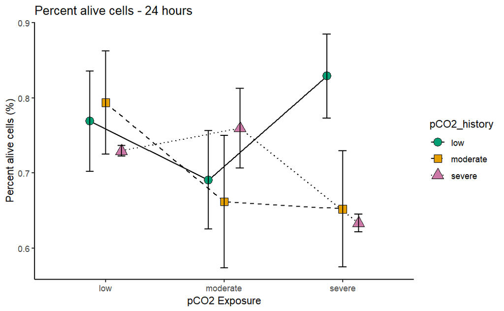

```r
# 24 HOURS

# stacked proportion plot


Day1_PropLive_RxnNorm <- data_filt %>% # data %>%
  # edit data to suit out needs
  dplyr::filter(Date %in% 20230502) %>% # filter for desired date of rhte experiment
  dplyr::select(c('Date','pCO2_exposure','pCO2_history','SYBR_PI_prop_alive_ADJ')) %>%
  na.omit() %>%
  group_by(pCO2_exposure, pCO2_history) %>% # group by columns for treatment
  dplyr::summarise( # summarise to aquire the mean and SE for plotting
    PercLive_mean = mean(SYBR_PI_prop_alive_ADJ), # mean
    PercLive_sd = sd(SYBR_PI_prop_alive_ADJ), # sd
    n = n(), # count
    PercLive_se = PercLive_sd / sqrt(n)) %>% # SE
  # plot it
  ggplot(aes(x=pCO2_exposure, y=PercLive_mean, group=pCO2_history)) +
    geom_line(aes(group = factor(pCO2_history), linetype = pCO2_history), size = 0.5, position=position_dodge(.4)) +  # connect a line between variables
    scale_linetype_manual(values=c("solid", "dashed", "dotted")) +
    geom_point(aes(shape=pCO2_history, fill=pCO2_history), size = 4,position=position_dodge(.4)) +
    scale_shape_manual(values=c(21, 22, 24)) + # filled circle, filled triangle, and X
    scale_fill_manual(values = c("#009E73","#E69F00", "#CC79A7")) +
    geom_errorbar(aes(ymin=(PercLive_mean)-(PercLive_se),
                      ymax=(PercLive_mean)+(PercLive_se)),
                  width=.2,position=position_dodge(.4)) +
    # geom_jitter() +
    theme_classic() +
    theme(panel.grid.major = element_blank(), panel.grid.minor = element_blank()) +
    ggtitle("Percent alive cells - 24 hours") +
    labs(y= "Percent alive cells (%)", x = "pCO2 Exposure") # +
   # facet_wrap(~pCO2_history)
Day1_PropLive_RxnNorm
```

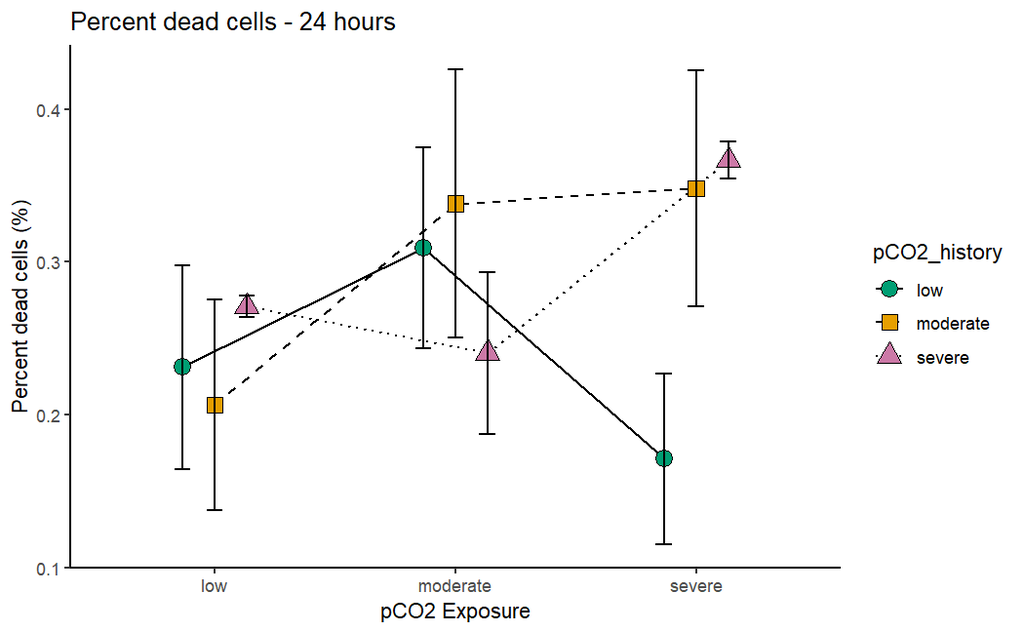

```r
Day1_PropDead_RxnNorm <- data_filt %>% # data %>%
  # edit data to suit out needs
  dplyr::filter(Date %in% 20230502) %>% # filter for desired date of rhte experiment
  dplyr::select(c('Date','pCO2_exposure','pCO2_history','SYBR_PI_prop_dead_ADJ')) %>%
  na.omit() %>%
  group_by(pCO2_exposure, pCO2_history) %>% # group by columns for treatment
  dplyr::summarise( # summarise to aquire the mean and SE for plotting
    PercDead_mean = mean(SYBR_PI_prop_dead_ADJ), # mean
    PercDead_sd = sd(SYBR_PI_prop_dead_ADJ), # sd
    n = n(), # count
    PercDead_se = PercDead_sd / sqrt(n)) %>% # SE
  # plot it
  ggplot(aes(x=pCO2_exposure, y=PercDead_mean, group=pCO2_history, fill =pCO2_history)) +
    geom_line(aes(group = factor(pCO2_history), linetype = pCO2_history), size = 0.5, position=position_dodge(.4)) +  # connect a line between variables
    scale_linetype_manual(values=c("solid", "dashed", "dotted")) +
    geom_point(aes(shape=pCO2_history, fill=pCO2_history), size = 4,position=position_dodge(.4)) +
    scale_shape_manual(values=c(21, 22, 24)) + # filled circle, filled triangle, and X
    scale_fill_manual(values = c("#009E73","#E69F00", "#CC79A7")) +
    geom_errorbar(aes(ymin=(PercDead_mean)-(PercDead_se),
                      ymax=(PercDead_mean)+(PercDead_se)),
                  width=.2,position=position_dodge(.4)) +
    # geom_jitter() +
    theme_classic() +
    theme(panel.grid.major = element_blank(), panel.grid.minor = element_blank()) +
    ggtitle("Percent dead cells - 24 hours") +
    labs(y= "Percent dead cells (%)", x = "pCO2 Exposure") #+
   # facet_wrap(~pCO2_history)
Day1_PropDead_RxnNorm
```

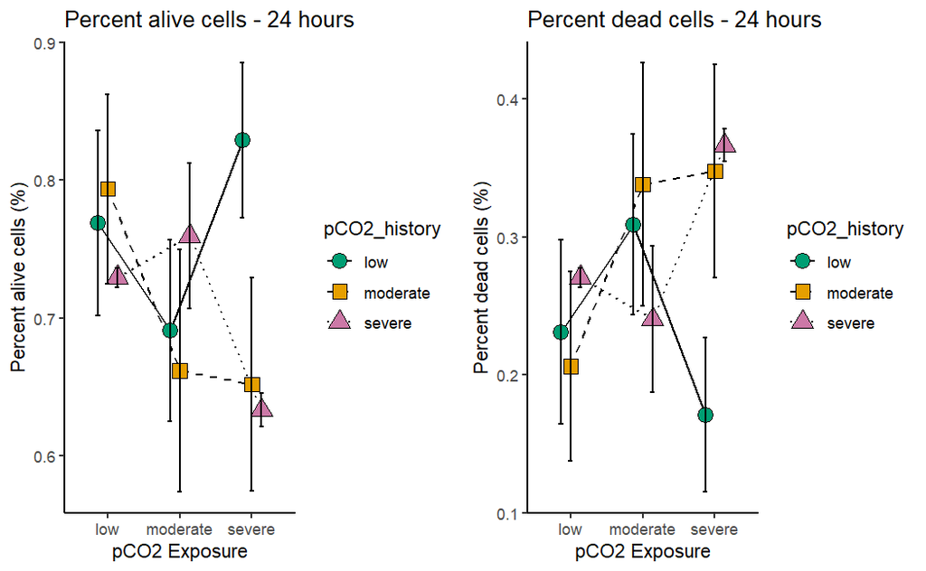

```r
ggarrange(Day1_PropLive_RxnNorm, Day1_PropDead_RxnNorm)
```

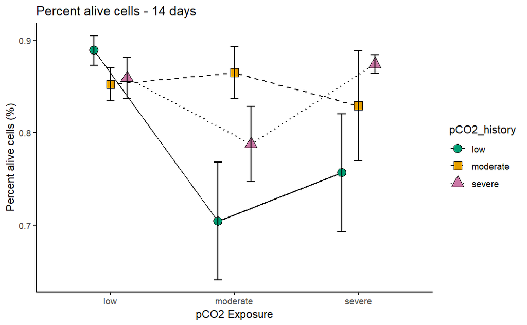

```r
# DAY 14 OF EXPERIMENT



Day14_PropLive_RxnNorm <- data_filt %>% # data %>%
  # edit data to suit out needs
  dplyr::filter(Date %in% 20230516) %>% # filter for desired date of rhte experiment
  dplyr::select(c('Date','pCO2_exposure','pCO2_history','SYBR_PI_prop_alive_ADJ')) %>%
  na.omit() %>%
  group_by(pCO2_exposure, pCO2_history) %>% # group by columns for treatment
  dplyr::summarise( # summarise to aquire the mean and SE for plotting
    PercLive_mean = mean(SYBR_PI_prop_alive_ADJ), # mean
    PercLive_sd = sd(SYBR_PI_prop_alive_ADJ), # sd
    n = n(), # count
    PercLive_se = PercLive_sd / sqrt(n)) %>% # SE
  # plot it
  ggplot(aes(x=pCO2_exposure, y=PercLive_mean, group=pCO2_history)) +
    geom_line(aes(group = factor(pCO2_history), linetype = pCO2_history), size = 0.5, position=position_dodge(.4)) +  # connect a line between variables
    scale_linetype_manual(values=c("solid", "dashed", "dotted")) +
    geom_point(aes(shape=pCO2_history, fill=pCO2_history), size = 4,position=position_dodge(.4)) +
    scale_fill_manual(values = c("#009E73","#E69F00", "#CC79A7")) +
    geom_errorbar(aes(ymin=(PercLive_mean)-(PercLive_se),
                      ymax=(PercLive_mean)+(PercLive_se)),
                  width=.2,position=position_dodge(.4)) +
    # geom_jitter() +
    theme_classic() +
    theme(panel.grid.major = element_blank(), panel.grid.minor = element_blank()) +
    scale_shape_manual(values=c(21, 22, 24)) + # filled circle, filled triangle, and X
    ggtitle("Percent alive cells - 14 days") +
    labs(y= "Percent alive cells (%)", x = "pCO2 Exposure") #+
    #facet_wrap(~pCO2_history)
Day14_PropLive_RxnNorm
```

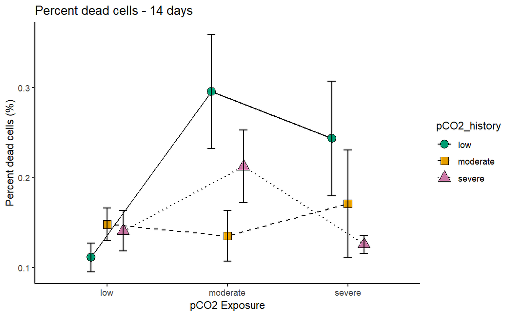

```r
Day14_PropDead_RxnNorm <- data_filt %>% # data %>%
  # edit data to suit out needs
  dplyr::filter(Date %in% 20230516) %>% # filter for desired date of rhte experiment
  dplyr::select(c('Date','pCO2_exposure','pCO2_history','SYBR_PI_prop_dead_ADJ')) %>%
  na.omit() %>%
  group_by(pCO2_exposure, pCO2_history) %>% # group by columns for treatment
  dplyr::summarise( # summarise to aquire the mean and SE for plotting
    PercDead_mean = mean(SYBR_PI_prop_dead_ADJ), # mean
    PercDead_sd = sd(SYBR_PI_prop_dead_ADJ), # sd
    n = n(), # count
    PercDead_se = PercDead_sd / sqrt(n)) %>% # SE
  # plot it
  ggplot(aes(x=pCO2_exposure, y=PercDead_mean, group=pCO2_history)) +
    geom_line(aes(group = factor(pCO2_history), linetype = pCO2_history), size = 0.5, position=position_dodge(.4)) +  # connect a line between variables
    scale_linetype_manual(values=c("solid", "dashed", "dotted")) +
    geom_point(aes(shape=pCO2_history, fill=pCO2_history), size = 4,position=position_dodge(.4)) +
    theme_classic() +
    theme(panel.grid.major = element_blank(), panel.grid.minor = element_blank()) +
    scale_shape_manual(values=c(21, 22, 24)) + # filled circle, filled triangle, and X
    scale_fill_manual(values = c("#009E73","#E69F00", "#CC79A7")) +
    geom_errorbar(aes(ymin=(PercDead_mean)-(PercDead_se),
                      ymax=(PercDead_mean)+(PercDead_se)),
                  width=.2,position=position_dodge(.4)) +
    theme_classic() +
    ggtitle("Percent dead cells - 14 days") +
    labs(y= "Percent dead cells (%)", x = "pCO2 Exposure")# +
   # facet_wrap(~pCO2_history)
Day14_PropDead_RxnNorm
```

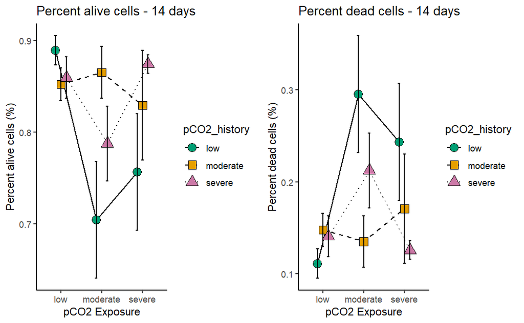

```r
ggarrange(Day14_PropLive_RxnNorm, Day14_PropDead_RxnNorm)
```

```r
library(ggrepel)
data_filt %>% # data %>%
  # edit data to suit out needs
  dplyr::filter(Date %in% 20230516) %>% # filter for desired date of rhte experiment
  dplyr::select(c('Date','Scallop_ID','pCO2_exposure','pCO2_history','SYBR_PI_prop_alive_ADJ')) %>%
  na.omit() %>%
  dplyr::filter(!Scallop_ID %in% 5) %>%
 # dplyr::filter(!Scallop_ID %in% 5)
  ggplot(aes(x=pCO2_exposure, y=SYBR_PI_prop_alive_ADJ, label=Scallop_ID)) +
      geom_boxplot(alpha = 0.5) +
      #geom_dotplot(binaxis = 'y', stackdir='center', dotsize=1) +
      #geom_text_repel(arrow = arrow(length=unit(0.2,"npc")),box.padding=1) +
      theme_bw()+
      geom_text(aes(label=Scallop_ID), size = 3.5) +
     # #scale_color_manual(values = c("#0072B2", "#D55E00")) + # colorblindness palette blue and orange
     #  theme_classic() +
     #  theme(legend.position = "none") +
      facet_wrap(~pCO2_history)


# STACKED BAR PLOTS - i thin this is the best way to display the data
pd <- position_dodge2(width = 0.2)
Day1_StackedBar <- data_filt %>% # data %>%
    # edit data to suit out needs
    dplyr::filter(Date %in% 20230502) %>% # filter for desired date of rhte experiment
    dplyr::select(c('Date','pCO2_exposure','pCO2_history','SYBR_PI_prop_alive_ADJ', 'SYBR_PI_prop_dead_ADJ')) %>%
    na.omit() %>%
    tidyr::pivot_longer(!c(Date,pCO2_exposure,pCO2_history), names_to = "Type", values_to = "Proportion") %>%
    group_by(pCO2_exposure, pCO2_history, Type) %>% # group by columns for treatment
    dplyr::summarise( # summarise to aquire the mean and SE for plotting
    Perc_mean = mean(Proportion), # mean
    Perc_sd = sd(Proportion), # sd
    n = n(), # count
    Perc_se = Perc_sd / sqrt(n)) %>% # SE
    dplyr::mutate(y_pos = cumsum(Perc_mean)) %>%
    dplyr::mutate(Type = factor(Type, levels=c('SYBR_PI_prop_dead_ADJ','SYBR_PI_prop_alive_ADJ'))) %>% #reorder for stacks
      ggplot(aes(x = pCO2_exposure,
                 y = Perc_mean,
                 fill = pCO2_history,
                 #group= pCO2_exposure,
                 alpha = Type)) +
      geom_bar(stat = "identity",
               width=0.7) +
      scale_fill_manual(values = c("#009E73","#E69F00", "#CC79A7")) +
      #scale_fill_manual(values = c("#0072B2", "#D55E00")) + # colorblindness palette blue and orange
      geom_errorbar(aes(ymax = y_pos + Perc_se,
                        ymin=  y_pos - Perc_se),
                    stat = "identity",
                    width = 0.1, # removed the error bar ticks
                    alpha = 0.7,
                    position = pd) +
      facet_wrap(~pCO2_history) +
      scale_alpha_manual(values=c(seq(0.3,1, length.out = 3))) +
      theme_classic() +
      scale_y_continuous(breaks = seq(from = 0, to = 1, by = 0.10)) +
      ylim(0,1.1)+
      theme(legend.position = "none") +
      ylab("Percent live v. dead hemocytes") +
      ggtitle("Day 1: Cell Viability")
Day1_StackedBar



Day14_StackedBar <- data_filt %>% # data %>%
    # edit data to suit out needs
    dplyr::filter(Date %in% 20230516) %>% # filter for desired date of rhte experiment
    dplyr::select(c('Date', 'Scallop_ID', 'pCO2_exposure','pCO2_history','SYBR_PI_prop_alive_ADJ', 'SYBR_PI_prop_dead_ADJ')) %>%
    na.omit() %>%
    tidyr::pivot_longer(!c(Date,pCO2_exposure,pCO2_history), names_to = "Type", values_to = "Proportion") %>%
    group_by(pCO2_exposure, pCO2_history, Type) %>% # group by columns for treatment
    dplyr::summarise( # summarise to aquire the mean and SE for plotting
    Perc_mean = mean(Proportion), # mean
    Perc_sd = sd(Proportion), # sd
    n = n(), # count
    Perc_se = Perc_sd / sqrt(n)) %>% # SE
    dplyr::mutate(y_pos = cumsum(Perc_mean)) %>%
    dplyr::mutate(Type = factor(Type, levels=c('SYBR_PI_prop_dead_ADJ','SYBR_PI_prop_alive_ADJ'))) %>% #reorder for stacks
      ggplot(aes(x = pCO2_exposure,
                 y = Perc_mean,
                 fill = pCO2_history,
                 #group= pCO2_exposure,
                 alpha = Type)) +
      geom_bar(stat = "identity",
               width=0.7) +
      scale_fill_manual(values = c("#009E73","#E69F00", "#CC79A7")) +
      #scale_fill_manual(values = c("#0072B2", "#D55E00")) + # colorblindness palette blue and orange
      geom_errorbar(aes(ymax = y_pos + Perc_se,
                        ymin=  y_pos - Perc_se),
                    stat = "identity",
                    width = 0.1, # removed the error bar ticks
                    alpha = 0.7,
                    position = pd) +
      facet_wrap(~pCO2_history) +
      scale_alpha_manual(values=c(seq(0.3,1, length.out = 3))) +
      theme_classic() +
      scale_y_continuous(breaks = seq(from = 0, to = 1.1, by = 0.10)) +
      ylim(0,1.1)+
      theme(legend.position = "none") +
      ylab("Percent live v. dead hemocytes") +
      ggtitle("Day 14: Cell Viability")
Day14_StackedBar
```

[output not shown]

### Mitochondrial reactive oxygen species

- MitoSox Green, gated using the FL1 (FITC-H) and FL1 vs. FL2 to truncate cells (FITC-H v. PE-H)
- data is the Mean FL1

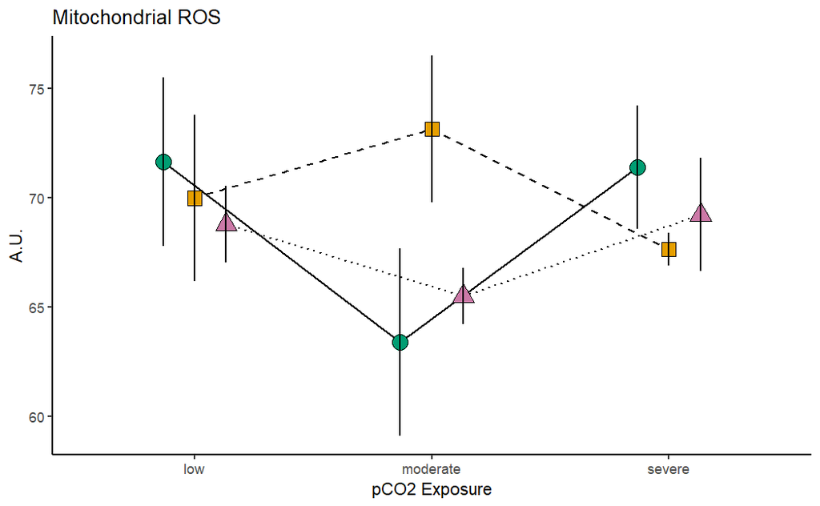

```r
# 24 hours

Day1_MitoROS_RxnNorm <- data_filt %>% # data %>%
  # edit data to suit out needs
  dplyr::filter(Date %in% 20230502) %>% # filter for desired date of rhte experiment
  dplyr::mutate(MitoSoxGreen_Mean_FL1 = as.numeric(MitoSoxGreen_Mean_FL1)) %>%
  dplyr::select(c('Date','pCO2_exposure','pCO2_history','MitoSoxGreen_Mean_FL1')) %>%
  na.omit() %>%
  group_by(pCO2_exposure, pCO2_history) %>% # group by columns for treatment
  dplyr::summarise( # summarise to aquire the mean and SE for plotting
    MitROS_mean = mean(MitoSoxGreen_Mean_FL1), # mean
    MitROS_sd = sd(MitoSoxGreen_Mean_FL1), # sd
    n = n(), # count
    MitROS_se = MitROS_sd / sqrt(n)) %>% # SE
  # plot it
  ggplot(aes(x=pCO2_exposure, y=MitROS_mean, group=pCO2_history)) +
    geom_line(aes(group = factor(pCO2_history), linetype = pCO2_history), size = 0.5, position=position_dodge(.4)) +  # connect a line between variables
    scale_linetype_manual(values=c("solid", "dashed", "dotted")) +
    geom_point(aes(shape=pCO2_history, fill=pCO2_history), size = 4.5,position=position_dodge(.4)) +
    scale_shape_manual(values=c(21, 22, 24)) + # filled circle, filled triangle, and X
    scale_fill_manual(values=c("#009E73","#E69F00", "#CC79A7")) + # fill cicle white, triangle white, and jsut black for the X
    geom_errorbar(aes(ymin=(MitROS_mean)-(MitROS_se),
                      ymax=(MitROS_mean)+(MitROS_se)),
                  width=0,position=position_dodge(.4)) + # width dtermines the length of the end ticks
    # geom_jitter() +
    theme_classic() +
    theme(panel.grid.major = element_blank(), panel.grid.minor = element_blank(),legend.position = "none") +
    ggtitle("Mitochondrial ROS") +
    labs(y= "A.U.", x = "pCO2 Exposure") #+
    #facet_wrap(~pCO2_history)
Day1_MitoROS_RxnNorm
```

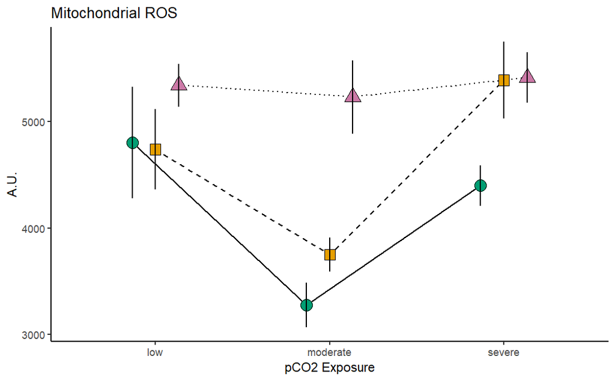

```r
#  14 days

Day14_MitoROS_RxnNorm <- data_filt %>% # data %>%
                          # edit data to suit out needs
                          dplyr::filter(Date %in% 20230516) %>% # filter for desired date of rhte experiment
                          dplyr::mutate(MitoSoxGreen_Mean_FL1 =
                                          as.numeric(sub(",", "", MitoSoxGreen_Mean_FL1))) %>%
                          # the % sign is included making this a character, omit the percent and make numeric!
                          dplyr::select(c('Date','pCO2_exposure','pCO2_history','MitoSoxGreen_Mean_FL1')) %>%
                          na.omit() %>%
                          group_by(pCO2_exposure, pCO2_history) %>% # group by columns for treatment
                          dplyr::summarise( # summarise to aquire the mean and SE for plotting
                            MitROS_mean = mean(MitoSoxGreen_Mean_FL1), # mean
                            MitROS_sd = sd(MitoSoxGreen_Mean_FL1), # sd
                            n = n(), # count
                            MitROS_se = MitROS_sd / sqrt(n)) %>% # SE
                          # plot it
                          ggplot(aes(x=pCO2_exposure, y=MitROS_mean, group=pCO2_history)) +
                            geom_line(aes(group = factor(pCO2_history),
                                          linetype = pCO2_history),
                                      size = 0.5,
                                      position=position_dodge(.4)) +  # connect a line between variables
                            scale_linetype_manual(values=c("solid", "dashed", "dotted")) +
                            geom_point(aes(shape=pCO2_history, fill=pCO2_history),
                                       size = 4.5,position=position_dodge(.4)) +
                            scale_shape_manual(values=c(21, 22, 24)) + # filled circle, filled triangle, and X
                            scale_fill_manual(values=
                                                c("#009E73","#E69F00", "#CC79A7")) +
                            # fill cicle white, triangle white, and jsut black for the X
                            geom_errorbar(aes(ymin=(MitROS_mean)-(MitROS_se),
                                              ymax=(MitROS_mean)+(MitROS_se)),
                                          width=0,position=position_dodge(.4)) +
                            # width dtermines the length of the end ticks
                            # geom_jitter() +
                            theme_classic() +
                            theme(panel.grid.major = element_blank(),
                                  panel.grid.minor = element_blank(),
                                  legend.position = "none") +
                            ggtitle("Mitochondrial ROS") +
                            labs(y= "A.U.", x = "pCO2 Exposure")# +
                            #facet_wrap(~pCO2_history)
Day14_MitoROS_RxnNorm
```

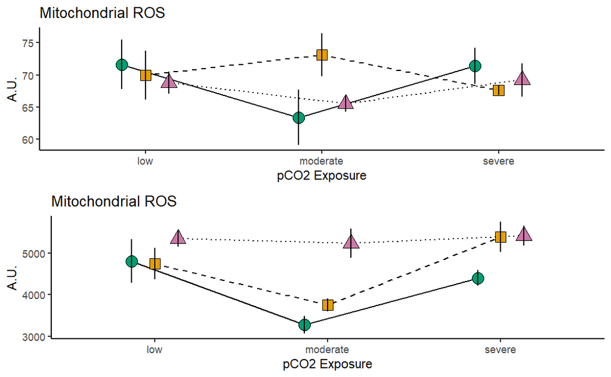

```r
ggarrange(Day1_MitoROS_RxnNorm, Day14_MitoROS_RxnNorm, nrow=2)
```

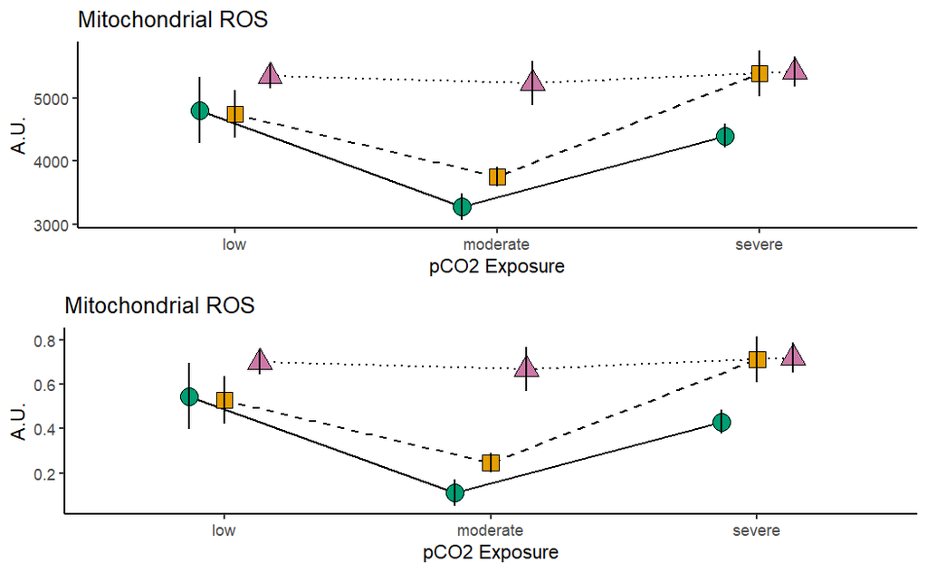

```r
# porototype thenormalization of AUs
# 0-1 normalization == (x-min(x))/(max(x)-min(x))

# get min
D1_min_mtROS <- min((data_filt %>% # data %>%
                    # edit data to suit out needs
                    dplyr::filter(Date %in% 20230516) %>% # filter for desired date of rhte experiment
                    dplyr::mutate(MitoSoxGreen_Mean_FL1 = as.numeric(sub(",", "", MitoSoxGreen_Mean_FL1))) %>% # the % sign is included making this a character, omit the percent and make numeric!
                    dplyr::select(c('Date','pCO2_exposure','pCO2_history','MitoSoxGreen_Mean_FL1')) %>%
                    na.omit())$MitoSoxGreen_Mean_FL1)
# get max
D1_max_mtROS <- max((data_filt %>% # data %>%
                    # edit data to suit out needs
                    dplyr::filter(Date %in% 20230516) %>% # filter for desired date of rhte experiment
                    dplyr::mutate(MitoSoxGreen_Mean_FL1 = as.numeric(sub(",", "", MitoSoxGreen_Mean_FL1))) %>% # the % sign is included making this a character, omit the percent and make numeric!
                    dplyr::select(c('Date','pCO2_exposure','pCO2_history','MitoSoxGreen_Mean_FL1')) %>%
                    na.omit())$MitoSoxGreen_Mean_FL1)

# figure with this normalization
Day14_MitoROS_RxnNorm_NORMALIZED <- data_filt %>% # data %>%
                              # edit data to suit out needs
                              dplyr::filter(Date %in% 20230516) %>% # filter for desired date of rhte experiment
                              dplyr::mutate(MitoSoxGreen_Mean_FL1 = as.numeric(sub(",", "", MitoSoxGreen_Mean_FL1))) %>% # the % sign is included making this a character, omit the percent and make numeric!
                              dplyr::select(c('Date','pCO2_exposure','pCO2_history','MitoSoxGreen_Mean_FL1')) %>%
                              na.omit() %>%
                              dplyr::mutate(mtROS_normalized =
                                              (MitoSoxGreen_Mean_FL1-D1_min_mtROS)/(D1_max_mtROS-D1_min_mtROS)) %>% # 0-1 normalization normalized = (x-min(x))/(max(x)-min(x))
                              group_by(pCO2_exposure, pCO2_history) %>% # group by columns for treatment
                              dplyr::summarise( # summarise to aquire the mean and SE for plotting
                                MitROS_mean = mean(mtROS_normalized), # mean
                                MitROS_sd = sd(mtROS_normalized), # sd
                                n = n(), # count
                                MitROS_se = MitROS_sd / sqrt(n)) %>% # SE
                              # plot it
                              ggplot(aes(x=pCO2_exposure, y=MitROS_mean, group=pCO2_history)) +
                                geom_line(aes(group = factor(pCO2_history), linetype = pCO2_history), size = 0.5, position=position_dodge(.4)) +  # connect a line between variables
                                scale_linetype_manual(values=c("solid", "dashed", "dotted")) +
                                geom_point(aes(shape=pCO2_history, fill=pCO2_history), size = 4.5,position=position_dodge(.4)) +
                                scale_shape_manual(values=c(21, 22, 24)) + # filled circle, filled triangle, and X
                                scale_fill_manual(values=c("#009E73","#E69F00", "#CC79A7")) + # fill cicle white, triangle white, and jsut black for the X
                                geom_errorbar(aes(ymin=(MitROS_mean)-(MitROS_se),
                                                  ymax=(MitROS_mean)+(MitROS_se)),
                                              width=0,position=position_dodge(.4)) + # width dtermines the length of the end ticks
                                # geom_jitter() +
                                theme_classic() +
                                theme(panel.grid.major = element_blank(), panel.grid.minor = element_blank(),legend.position = "none") +
                                ggtitle("Mitochondrial ROS") +
                                labs(y= "A.U.", x = "pCO2 Exposure")# +
ggarrange(Day14_MitoROS_RxnNorm, Day14_MitoROS_RxnNorm_NORMALIZED, nrow=2)
```

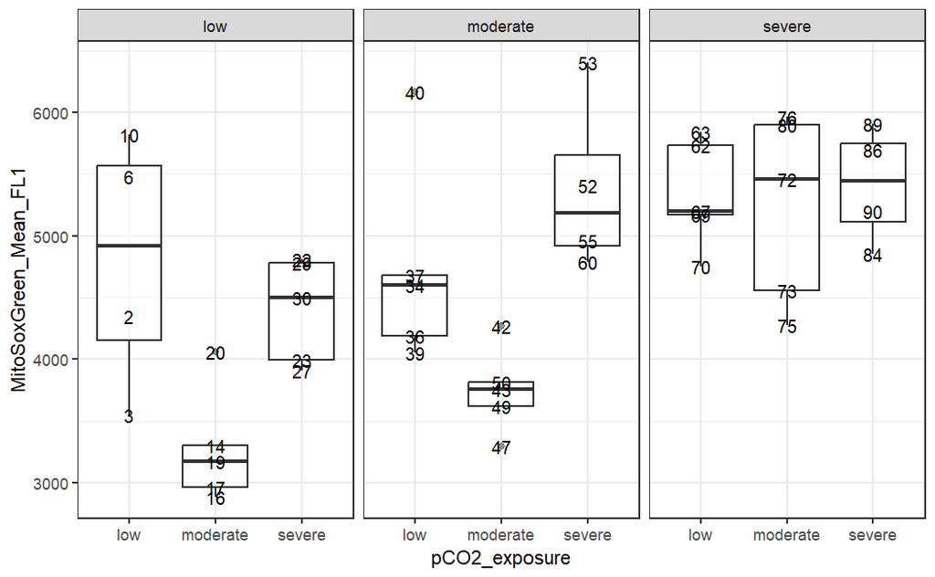

```r
data_filt %>% # data %>%
  # edit data to suit out needs
  dplyr::filter(Date %in% 20230516) %>% # filter for desired date of rhte experiment
  dplyr::select(c('Date','Scallop_ID','pCO2_exposure','pCO2_history','MitoSoxGreen_Mean_FL1')) %>%
  na.omit() %>%
  #dplyr::filter(!Scallop_ID %in% 5) %>%
 # dplyr::filter(!Scallop_ID %in% 5)
  ggplot(aes(x=pCO2_exposure, y=MitoSoxGreen_Mean_FL1, label=Scallop_ID)) +
      geom_boxplot(alpha = 0.5) +
      #geom_dotplot(binaxis = 'y', stackdir='center', dotsize=1) +
      #geom_text_repel(arrow = arrow(length=unit(0.2,"npc")),box.padding=1) +
      theme_bw()+
      geom_text(aes(label=Scallop_ID), size = 3.5) +
     # #scale_color_manual(values = c("#0072B2", "#D55E00")) + # colorblindness palette blue and orange
     #  theme_classic() +
     #  theme(legend.position = "none") +
      facet_wrap(~pCO2_history)
```

### Mitochondrial membrane potential

- JC-10 (compensated for CCCP), gated using the FL1 (FITC-H) and FL1 vs. FL2 to truncate cells (FITC-H v. PE-H)
- data is the ratio of ‘red to gree’ as the Jaggregate (positive membrane potential) : Monomer (low memrane potential) or the FL 2 : FL 1

[figure not shown]

```r
ggplot(Day14_filt,
                             aes(x = as.integer(factor(pCO2_baseline_change)) +
                                         cut_col,
                                       y =MitoSoxGreen_Mean_FL1,
                                       color=pCO2_history,
                                       fill= pCO2_history,
                                       shape=pCO2_exposure)) +
                             geom_line(data = Day14_MitSox_df_line,
                                        aes(y = mean_MitoSoxGreen_Mean_FL1,
                                            group = interaction(line_group)),
                                            # group = interaction(pCO2_history, pCO2_exposure)),
                                            # group = interaction(as.integer(pCO2_baseline_change), pCO2_history)
                                            size = 2,
                                            alpha = 0.1) +
                              stat_summary(fun.data= mean_se, geom="errorbar", width=0) +
                              stat_summary(fun=mean, geom="point", size=5)
```

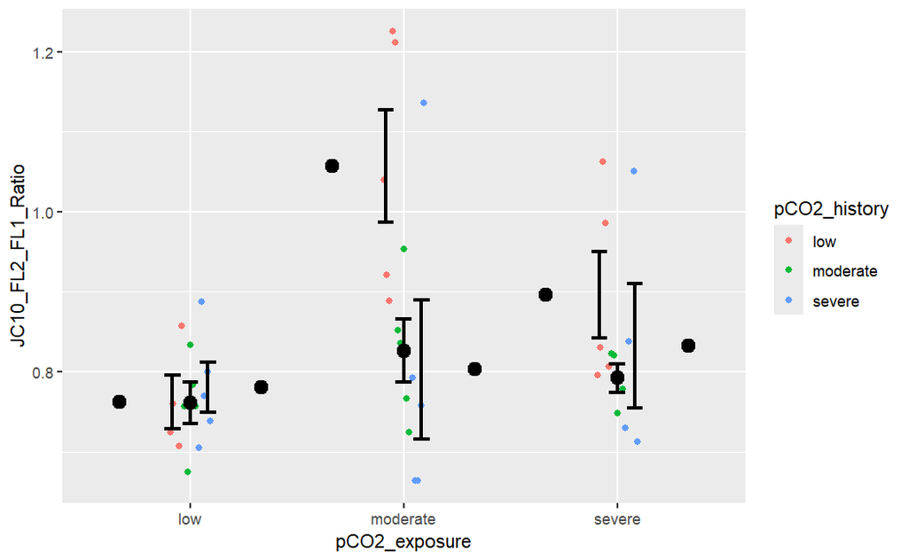

```r
Day14_MitoMemPot_RxnNorm
```

## Statistical analysis

### PERMANOVA

```r
library(vegan)
# METADATA
D1_metadata   <- Day1_datafilt  %>%
                      dplyr::select(Scallop_ID, pCO2_history, pCO2_exposure, SYBR_PI_prop_alive_ADJ, MitoSoxGreen_Mean_FL1, JC10_FL2_FL1_Ratio) %>%
                      dplyr::rename(sample.id = Scallop_ID) %>%
                      na.omit() %>% # takeso out smaple Ids that had even one NA in the DV data
                      dplyr::select(-c(SYBR_PI_prop_alive_ADJ, MitoSoxGreen_Mean_FL1, JC10_FL2_FL1_Ratio))

D14_metadata  <- Day14_datafilt %>%
                      dplyr::select(Scallop_ID, pCO2_history, pCO2_exposure, SYBR_PI_prop_alive_ADJ, MitoSoxGreen_Mean_FL1, JC10_FL2_FL1_Ratio) %>%
                      dplyr::rename(sample.id = Scallop_ID) %>%
                      na.omit() %>%  # takeso out smaple Ids that had even one NA in the DV data
                      dplyr::select(-c(SYBR_PI_prop_alive_ADJ, MitoSoxGreen_Mean_FL1, JC10_FL2_FL1_Ratio))

# CALL JUST THE DVs FOR THE MATRIX
D1_depvars        <- Day1_datafilt[, c('SYBR_PI_prop_alive_ADJ', 'MitoSoxGreen_Mean_FL1', 'JC10_FL2_FL1_Ratio'), drop = FALSE]
D1_depvars_OM     <- na.omit(D1_depvars)
D1_distance_euc   <- vegdist(D1_depvars_OM, "euclidean")

D14_depvars       <- Day14_datafilt[, c('SYBR_PI_prop_alive_ADJ', 'MitoSoxGreen_Mean_FL1', 'JC10_FL2_FL1_Ratio'), drop = FALSE]
D14_depvars_OM    <- na.omit(D14_depvars)
D14_distance_euc  <- vegdist(D14_depvars_OM, "euclidean")

# CREATE SQUARE MATRIX ASSIGN ROW NAMES AND COLUMN NAMES AS THE GROUP VAR
D1_scallop_IDs_OM          <- (Day1_datafilt %>%
                                 dplyr::select(c('Scallop_ID', 'SYBR_PI_prop_alive_ADJ', 'MitoSoxGreen_Mean_FL1', 'JC10_FL2_FL1_Ratio')) %>%
                                 na.omit())$Scallop_ID # omit NAs as we did for the euclidean dist amtrix data and call just the IDs
D1_distance_mtx            <- as.matrix(D1_distance_euc)
rownames(D1_distance_mtx)  <- D1_scallop_IDs_OM
colnames(D1_distance_mtx)  <- D1_scallop_IDs_OM

D14_scallop_IDs_OM          <- (Day14_datafilt %>%
                                 dplyr::select(c('Scallop_ID', 'SYBR_PI_prop_alive_ADJ', 'MitoSoxGreen_Mean_FL1', 'JC10_FL2_FL1_Ratio')) %>%
                                 na.omit())$Scallop_ID # omit NAs as we did for the euclidean dist amtrix data and call just the IDs
D14_distance_mtx           <- as.matrix(D14_distance_euc)
rownames(D14_distance_mtx) <- D14_scallop_IDs_OM
colnames(D14_distance_mtx) <- D14_scallop_IDs_OM


# Then...
# CONVERT THE ROWNAME TO FIRST COLUMN, CONVERT TO DATAFRAME TO DO SO
D1_distance  <- tibble::rownames_to_column(as.data.frame(D1_distance_mtx), "sample.id")
D14_distance  <- tibble::rownames_to_column(as.data.frame(D14_distance_mtx), "sample.id")


# NOW USE INNER_JOIN TO MERGE THE METADATA
D1_meta_distance   <- inner_join(D1_distance,  D1_metadata, by = "sample.id")
D14_meta_distance  <- inner_join(D14_distance,  D14_metadata, by = "sample.id")


# get the dist matrix
# * isolate the distance data - for the LHS (DV) of adonis!
D1_dist   <- D1_meta_distance  %>% dplyr::select(all_of(D1_meta_distance$sample.id)) %>% as.dist()
D14_dist  <- D14_meta_distance  %>% dplyr::select(all_of(D14_meta_distance$sample.id)) %>% as.dist()


# RUN ADONIS
# formula as () LHS (disc required!) ~ RHS (your metadata), data = metadata, perms)
permutations = 10000
D1_adonis_run   <- adonis2(D1_dist  ~ pCO2_history*pCO2_exposure, data=D1_meta_distance, perms = permutations)
D14_adonis_run  <- adonis2(D14_dist ~ pCO2_history*pCO2_exposure, data=D14_meta_distance, perms = permutations)



# Paiwrise DAY 14
# METADATA (IV)
D14_HxL_history_metadata <- D14_meta_distance %>% dplyr::filter(pCO2_history %in% c('severe', 'low'))
D14_HxM_history_metadata <- D14_meta_distance %>% dplyr::filter(pCO2_history %in% c('severe', 'moderate'))
D14_LxM_history_metadata <- D14_meta_distance %>% dplyr::filter(pCO2_history %in% c('low', 'moderate'))
# DISTANCE (DV)
D14_HxL_history_dist    <- D14_meta_distance %>%
                            dplyr::filter(sample.id %in% D14_HxL_history_metadata$sample.id) %>%
                            dplyr::select(D14_HxL_history_metadata$sample.id) %>%
                            as.dist()
D14_HxM_history_dist   <- D14_meta_distance %>%
                            dplyr::filter(sample.id %in% D14_HxM_history_metadata$sample.id) %>%
                            dplyr::select(D14_HxM_history_metadata$sample.id) %>%
                            as.dist()
D14_LxM_history_dist   <- D14_meta_distance %>%
                            dplyr::filter(sample.id %in% D14_LxM_history_metadata$sample.id) %>%
                            dplyr::select(D14_LxM_history_metadata$sample.id) %>%
                            as.dist()
# RUN ADONIS FOR EACH PAIR
D14_adonis_HxL_history   <- adonis2(D14_HxL_history_dist  ~ pCO2_history, data=D14_HxL_history_metadata, perms = permutations)
D14_adonis_HxM_history   <- adonis2(D14_HxM_history_dist  ~ pCO2_history, data=D14_HxM_history_metadata, perms = permutations)
D14_adonis_LxM_history   <- adonis2(D14_LxM_history_dist  ~ pCO2_history, data=D14_LxM_history_metadata, perms = permutations)
```

### Two way ANOVAs

- Run two way model for pCO2 history x pCO2 exposure effects
- Then explore within history for effects of pCO2 exposure

```r
summary(aov(D1_PropAlive_Twoway)) # no effect
```

[output not shown]

```r
D14_mtROS_Low_Dunns
```

```
Dunn (1964) Kruskal-Wallis multiple comparison
  p-values adjusted with the Benjamini-Hochberg method.
```

| Comparison | Z | P.unadj | P.adj |
| --- | --- | --- | --- |
| low - moderate | 2.3697163 | 0.01780174 | 0.05340521 |
| low - severe | 0.3741657 | 0.70828101 | 0.70828101 |
| moderate - severe | -2.1166010 | 0.03429372 | 0.05144058 |

```r
#              Df Sum Sq Mean Sq F value Pr(>F)
# pCO2_history  2   2263  1131.5   5.784 0.0174 *
# Residuals    12   2347   195.6
# 2 observations deleted due to missingness
TukeyHSD(aov(D1_Mito_Baseline))
```

```
  Tukey multiple comparisons of means
    95% family-wise confidence level

Fit: aov(formula = D1_Mito_Baseline)

$pCO2_history
                     diff        lwr      upr     p adj
moderate-low    29.459227   5.859876 53.05858 0.0153229
severe-low      20.022582  -3.576769 43.62193 0.1003391
severe-moderate -9.436645 -33.035996 14.16271 0.5513766
```

## BASELINE: One way ANOVA pCO2 history effects (UNDER MATCHED EXPOSURE ONLY)

| Date | FlowCyProbe | Test | Shapiro | Levenes | DF | Fvalue | chisquared | Pvalue |
| --- | --- | --- | --- | --- | --- | --- | --- | --- |
| 20230502 | JC10_FL2_FL1_Ratio | One-way ANOVA | 0.975809194701668 | 0.732900044548202 | 2 | 5.784 | NA | 0.01742 |
| 20230516 | MitoSoxGreen_Mean_FL1 | Kruskal Wallis | 0.986488371677269 | 0.0195745195024193 | 2 | NA | 6.31 | 0.04264 |

## EXPOSURE: One way ANOVA pCO2 exposure effects WITHIN HISTORY

- Effect of pCO2 exposure within each pCO2 history and for each dependent variable
- loop one way (kruskal wallis non param) and beta reg (survival data)

| pCO2_exposure | N | SYBR_PI_prop_alive_ADJ | sd | se | ci |
| --- | --- | --- | --- | --- | --- |
| low | 4 | 0.8890386 | 0.03187177 | 0.01593589 | 0.0507151 |
| moderate | 5 | 0.7045212 | 0.14199022 | 0.06349996 | 0.1763041 |
| severe | 5 | 0.7566827 | 0.14220507 | 0.06359604 | 0.1765709 |

```r
# 24 HOUR DATA - history x exposure tests



Day1_MitoSox_AOV <- aov(lm(MitoSoxGreen_Mean_FL1 ~ pCO2_history*pCO2_exposure, data=Day1_datafilt))
shapiro.test(resid(Day1_MitoSox_AOV)) # normal 0.4232
leveneTest(Day1_MitoSox_AOV) # 0.6705 PASS variance test
summary(Day1_MitoSox_AOV)
#                            Df Sum Sq Mean Sq F value Pr(>F)
# pCO2_history                2   71.2   35.59   0.683  0.512
# pCO2_exposure               2   63.6   31.79   0.610  0.549
# pCO2_history:pCO2_exposure  4  224.3   56.08   1.076  0.383
# Residuals                  36 1876.7   52.13



# 14 DAY EXPOSURE DATA  - history x exposure tests



Day14_MitoSox_AOV <- aov(lm(MitoSoxGreen_Mean_FL1 ~ pCO2_history*pCO2_exposure, data=Day14_datafilt))
shapiro.test(resid(Day14_MitoSox_AOV)) # normal 0.6608
leveneTest(Day14_MitoSox_AOV) # 0.2396 PASS variance test
summary(Day14_MitoSox_AOV)
#                             Df   Sum Sq Mean Sq F value   Pr(>F)
# pCO2_history                2 11336397 5668198  11.232 0.000162 ***
# pCO2_exposure               2  6723335 3361668   6.661 0.003456 **
# pCO2_history:pCO2_exposure  4  3810366  952591   1.888 0.133824
TukeyHSD(Day14_MitoSox_AOV)


# lets get them letters
mod_means_contr <- emmeans::emmeans(object = Day14_MitoSox_AOV,
                                    pairwise ~ "pCO2_exposure",
                                    adjust = "tukey")
mod_means <- multcomp::cld(object = mod_means_contr$emmeans,
                           Letters = letters)
 # pCO2_history emmean  SE df lower.CL upper.CL .group
 # low            4023 183 36     3651     4395  a
 # moderate       4603 183 36     4231     4975  a
 # severe         5252 183 36     4880     5624   b

 # pCO2_exposure emmean  SE df lower.CL upper.CL .group
 # moderate        4085 183 36     3713     4457  a
 # low             4823 183 36     4451     5195   b
 # severe          4968 183 36     4596     5340   b


mod_means_contr <- emmeans::emmeans(object = Day14_MitoSox_AOV,
                                    pairwise ~ "pCO2_history:pCO2_exposure",
                                    adjust = "tukey")
mod_means <- multcomp::cld(object = mod_means_contr$emmeans,
                           Letters = letters)
 # pCO2_history pCO2_exposure emmean  SE df lower.CL upper.CL .group
 # low          moderate        3277 291 35     2686     3868  a
 # moderate     moderate        3750 291 35     3159     4341  ab
 # low          severe          4400 291 35     3809     4990  abc
 # moderate     low             4739 291 35     4148     5330   bc
 # low          low             4801 325 35     4141     5462   bc
 # severe       severe          5185 291 35     4595     5776    c
 # severe       moderate        5230 291 35     4639     5820    c
 # moderate     severe          5319 291 35     4729     5910    c
 # severe       low             5340 291 35     4749     5930    c

mitosoxDay14 <- data_filt %>% # data %>%
  # edit data to suit out needs
  dplyr::filter(Date %in% 20230516) %>% # filter for desired date of rhte experiment
  dplyr::select(c('Date','Scallop_ID','pCO2_exposure','pCO2_history','MitoSoxGreen_Mean_FL1')) %>%
  na.omit() %>%
  dplyr::filter(pCO2_history %in% 'low') %>%
  dplyr::filter(!Scallop_ID %in% 5)


Day14_MitoSox_AOV_LOW <- aov(lm(MitoSoxGreen_Mean_FL1 ~ pCO2_exposure, data=mitosoxDay14))
shapiro.test(resid(Day14_MitoSox_AOV_LOW)) # normal 0.792
leveneTest(Day14_MitoSox_AOV_LOW) # 0.04912 * PASS variance test
qqnorm(resid(Day14_MitoSox_AOV_LOW))
TukeyHSD(Day14_MitoSox_AOV_LOW)
Day14_MitoSox_KW_LOW <- kruskal.test(MitoSoxGreen_Mean_FL1 ~ pCO2_exposure, data=mitosoxDay14)
Day14_MitoSox_KW_LOW # p-value = 0.03175
# Kruskal-Wallis chi-squared = 6.9, df = 2, p-value = 0.03175
Day14_SRH_Dunns <- dunnTest(MitoSoxGreen_Mean_FL1 ~ pCO2_exposure,
              data=mitosoxDay14,
              method="bh")      # Adjusts p-values for multiple comparisons;
Day14_SRH_Dunns
# low - moderate    2.3697163   0.01780174  0.05340521
# low - severe  0.3741657   0.70828101  0.70828101
# moderate - severe -2.1166010  0.03429372  0.05144058
```

```r
# 24 HOUR DATA - history x exposure tests


Day1_MitoMemPot_AOV <- aov(lm(JC10_FL2_FL1_Ratio ~ pCO2_history*pCO2_exposure, data=Day1_datafilt))
shapiro.test(resid(Day1_MitoMemPot_AOV)) #  normal 0.1992
leveneTest(Day1_MitoMemPot_AOV) # 0.7438 PASS variance test
summary(Day1_MitoMemPot_AOV)
#                             Df Sum Sq Mean Sq F value Pr(>F)
# pCO2_history                2   4126  2062.8   2.841 0.0736 .
# pCO2_exposure               2    677   338.4   0.466 0.6318
# pCO2_history:pCO2_exposure  4   1404   351.1   0.484 0.7476
# Residuals                  31  22507   726.0
TukeyHSD(Day1_MitoMemPot_AOV)
# $pCO2_history
#                      diff        lwr      upr     p adj
# moderate-low    24.221604  -1.321011 49.76422 0.0658178
# severe-low      16.972800  -9.038526 42.98413 0.2582674
# severe-moderate -7.248805 -32.791420 18.29381 0.7661487


Day1_MitoMemPot_SRH <- scheirerRayHare(JC10_FL2_FL1_Ratio ~ pCO2_history*pCO2_exposure, data=Day1_datafilt)
Day1_MitoMemPot_SRH
#                             Df Sum Sq      H p.value
# pCO2_history                2  972.9 7.1187 0.02846
# pCO2_exposure               2  245.0 1.7926 0.40808
# pCO2_history:pCO2_exposure  4  229.7 1.6804 0.79427
# Residuals                  31 3958.9
Day1_SRH_Dunns <- dunnTest(JC10_FL2_FL1_Ratio ~ pCO2_history,
              data=Day1_datafilt,
              method="bh")      # Adjusts p-values for multiple comparisons;
                                # See ?dunnTest for options
Day1_SRH_Dunns
# low - moderate    -2.572622   0.01009314  0.03027941
# low - severe  -1.395620   0.16282904  0.24424356
# moderate - severe 1.132258    0.25752615  0.25752615












# 14 DAY EXPOSURE DATA  - history x exposure tests




Day14_MitoMemPot_AOV <- aov(lm(JC10_FL2_FL1_Ratio ~ pCO2_history*pCO2_exposure, data=Day14_datafilt))
shapiro.test(resid(Day14_MitoMemPot_AOV)) #  non-normal 0.0006415
leveneTest(Day14_MitoMemPot_AOV) # 0.6969 PASS variance test
Day14_MitoMemPot_SRH <- scheirerRayHare(JC10_FL2_FL1_Ratio ~ pCO2_history*pCO2_exposure, data=Day14_datafilt)
Day14_MitoMemPot_SRH
#                             Df Sum Sq      H  p.value
# pCO2_history                2  588.0 3.7297 0.154920
# pCO2_exposure               2  963.8 6.1131 0.047051 * significant!
# pCO2_history:pCO2_exposure  4  975.4 6.1868 0.185627
# Residuals                  34 4070.8
Day14_SRH_Dunns <- dunnTest(JC10_FL2_FL1_Ratio ~ pCO2_exposure,
              data=Day14_datafilt,
              method="bh")      # Adjusts p-values for multiple comparisons;
                                # See ?dunnTest for options
Day14_SRH_Dunns
# low - moderate        -2.355507   0.01849744  0.05549231
# low - severe          -1.876431   0.06059618  0.09089426
# moderate - severe    0.393393 0.69402926  0.69402926


# follow up on a one way anova effect - severe was significat
Day14_MitoPot_Low <- Day14_datafilt %>% filter(pCO2_history %in% 'low')
Day14_MitoPot_Low_mod <- kruskal.test(JC10_FL2_FL1_Ratio~pCO2_exposure,data=Day14_MitoPot_Low) # we know its non normal
# Kruskal-Wallis chi-squared = 8.88, df = 2, p-value = 0.0118
Day14_KW_low_Dunns <- dunnTest(JC10_FL2_FL1_Ratio ~ pCO2_exposure,
              data=Day14_MitoPot_Low,
              method="bh")      # Adjusts p-values for multiple comparisons;
                                # See ?dunnTest for options
Day14_KW_low_Dunns
# low - moderate    -2.969848   0.002979467 0.0089384   ***
# low - severe  -1.697056   0.089686022 0.1345290
# moderate - severe 1.272792    0.203091788 0.2030918
```